# Relation

Gráficos de tipo relación, Seaborn maneja también el Scatterplot, entre otros.

```python
import seaborn as sns
import matplotlib.pyplot as plt
```

```python
tips = sns.load_dataset('tips')
tips.head(3)
```

|  | total_bill | tip | sex | smoker | day | time | size |
| --- | --- | --- | --- | --- | --- | --- | --- |
| 0 | 16.99 | 1.01 | Female | No | Sun | Dinner | 2 |
| 1 | 10.34 | 1.66 | Male | No | Sun | Dinner | 3 |
| 2 | 21.01 | 3.50 | Male | No | Sun | Dinner | 3 |

## Scatterplot

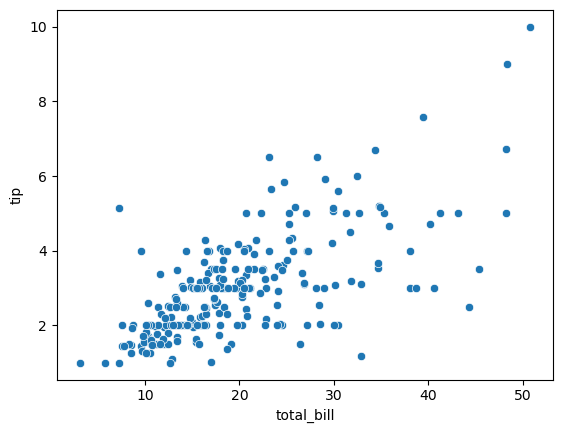

```python
#Grafico de dispersión
sns.scatterplot(data=tips,x='total_bill',y='tip')
plt.show()
```

Vamos a analizar la relación que existe entre la cuenta y el total de las propinas. Se puede ver un comportamiento de relación - > Entre mas crece la cuenta, tiende a crecer la propina, también hay casos atípicos

### Segmentando por día

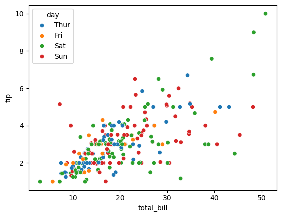

```python
#Grafico de dispersión
sns.scatterplot(data=tips,x='total_bill',y='tip',hue='day')
plt.show()
```

Podemos ver que por color se hace la segmentación y por ciertos días hay un consumo mayor en la cuenta y a su vez una mayor propina.

### Estilo dependiente de 'time'

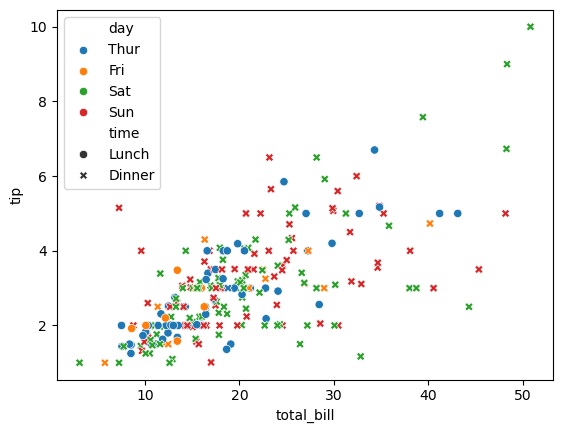

```python
#Grafico de dispersión
sns.scatterplot(data=tips,x='total_bill',y='tip',hue='day',style='time')
plt.show()
```

Aquí hay otro tipo de segmentación en el que gráficamente se puedde distinguir entre `lunch` y `dinner`, por medio de un marcador diferente. Entonces como se puede apreciar, parece que para `dinner` hay tanto un consumo mayor en `total_bill` y `tip`

### Tamaño de marcador relacionado a size(número de comensales)

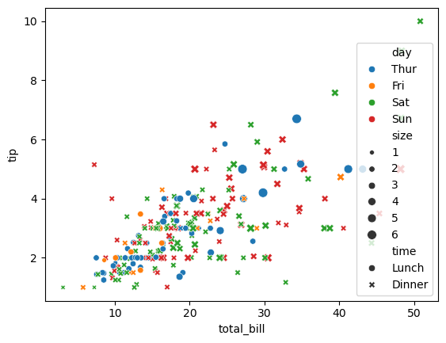

```python
#Grafico de dispersión
sns.scatterplot(data=tips,x='total_bill',y='tip',hue='day',style='time',size='size')
plt.show()
```

La leyenda anterior me molesta la gráfica así que vamos a moverla.

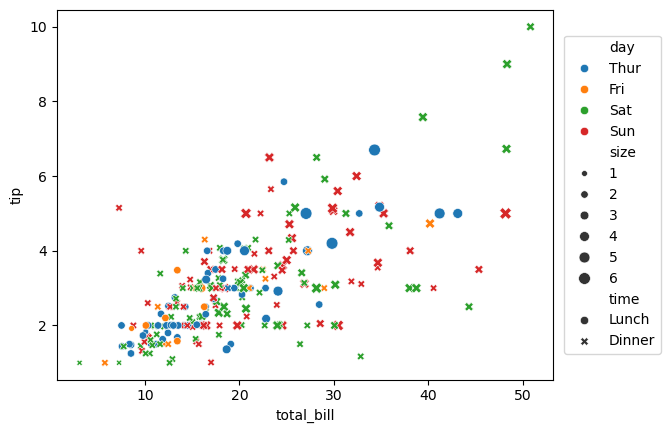

```python
#Grafico de dispersión
sns.scatterplot(data=tips,x='total_bill',y='tip',hue='day',style='time',size='size')
plt.legend(loc='center',bbox_to_anchor=(1.12,0.5))
plt.show()
```

Así mi leyenda ya no me estorba y puedo realizar un analisis correctamente.

### Definiendo markers

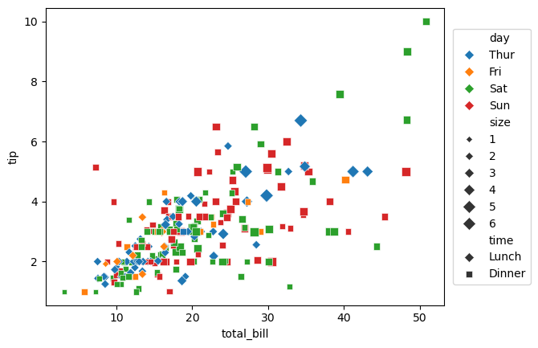

```python
#Grafico de dispersión
marker = {'Lunch':'D','Dinner':'s'}
sns.scatterplot(data=tips,x='total_bill',y='tip',hue='day',style='time',size='size',markers=marker)
plt.legend(loc='center',bbox_to_anchor=(1.12,0.5))
plt.show()
```

### Ajustando tamaño

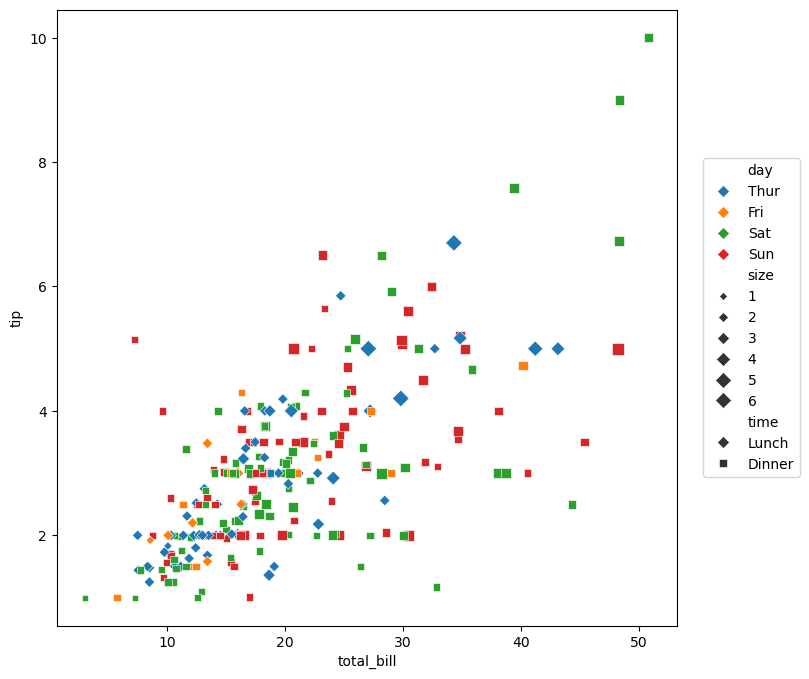

```python
#Grafico de dispersión
marker = {'Lunch':'D','Dinner':'s'}
plt.figure(figsize=(8,8))
sns.scatterplot(data=tips,x='total_bill',y='tip',hue='day',style='time',size='size',markers=marker)
plt.legend(loc='center',bbox_to_anchor=(1.12,0.5))
plt.show()
```

## Lineplot

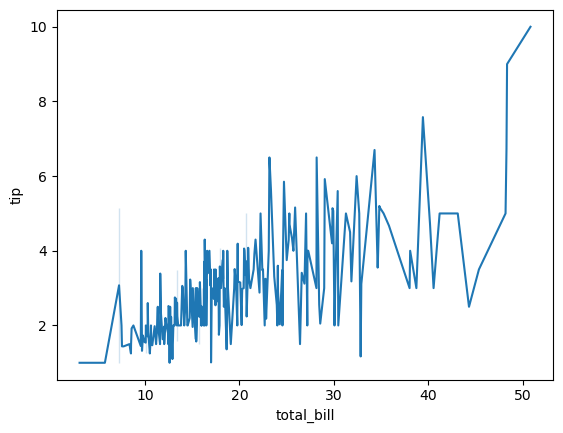

```python
#Grafico lineplot
sns.lineplot(data=tips,x='total_bill',y='tip')
plt.show()
```

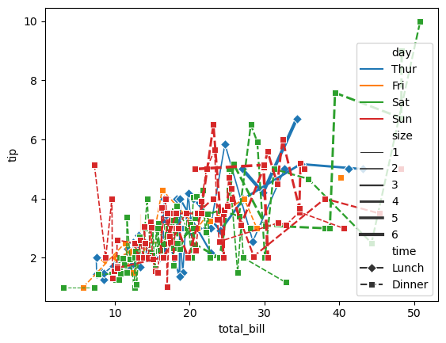

```python
#Grafico lineplot
sns.lineplot(data=tips,x='total_bill',y='tip',hue='day',style='time',size='size',markers=marker)
plt.show()
```

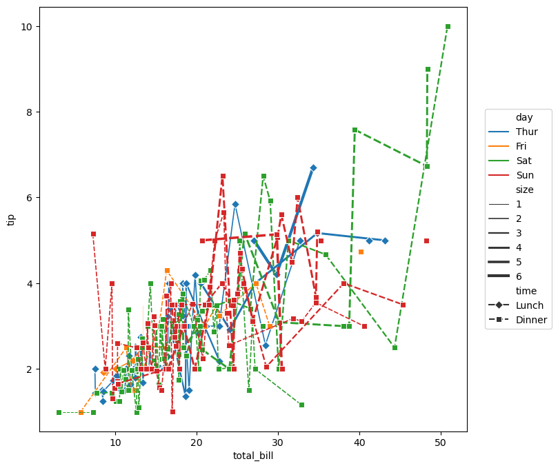

```python
#Grafico lineplot
marker = {'Lunch':'D','Dinner':'s'}
plt.figure(figsize=(8,8))
sns.lineplot(data=tips,x='total_bill',y='tip',hue='day',style='time',size='size',markers=marker)
plt.legend(loc='center',bbox_to_anchor=(1.12,0.5))
plt.show()
```

## Relplot

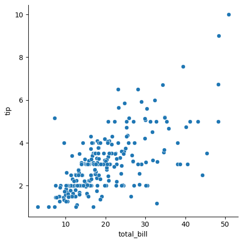

```python
#Grafico relplot
sns.relplot(data=tips,x='total_bill',y='tip')
plt.show()
```

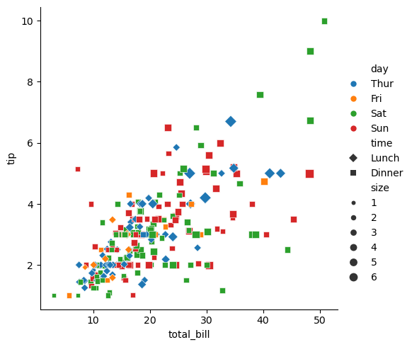

```python
#Grafico replot
sns.relplot(data=tips,x='total_bill',y='tip',hue='day',style='time',size='size',markers=marker)
plt.show()
```

### Usando Kind

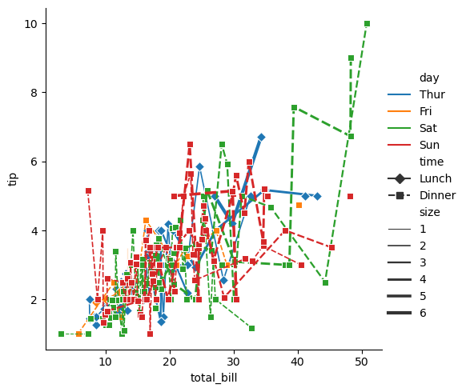

```python
#Grafico replot
sns.relplot(data=tips,x='total_bill',y='tip',hue='day',style='time',size='size',markers=marker,kind='line')
plt.show()
```

### Usando col = 'day' & kind = 'scatter'

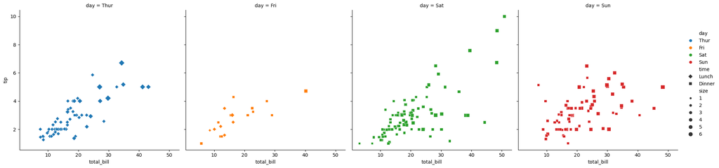

```python
#Grafico replot
sns.relplot(data=tips,x='total_bill',y='tip',hue='day',style='time',size='size',markers=marker,col='day',kind='scatter')
plt.show()
```

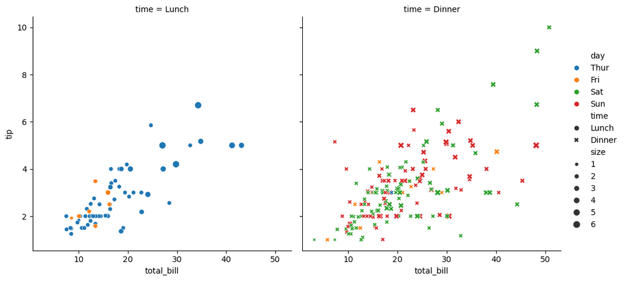

```python
#Grafico replot
sns.relplot(data=tips,x='total_bill',y='tip',hue='day',style='time',size='size',col='time',kind='scatter')
plt.show()
```

## Extra:

Aporte de Carlos Felipe Saldarriaga Bejarano  
También podemos usar pairplot, te permite ver comparativas de pares de variables y analizar su comportamiento en un solo gráfico.

```
sns.pairplot(data=tips,hue='day')
plt.show()
```

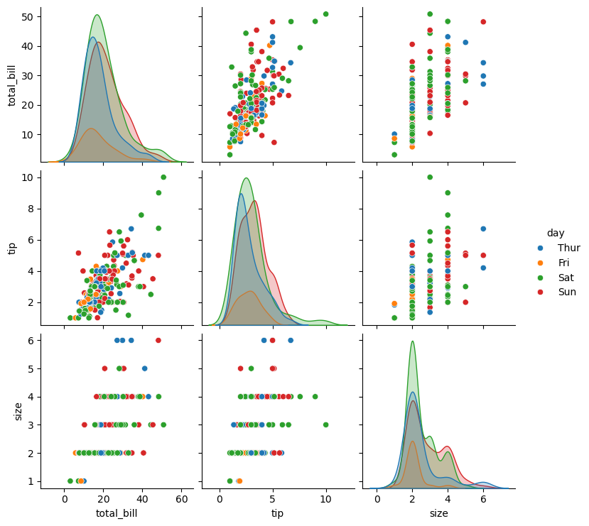

```python
sns.pairplot(data=tips,hue='day')
plt.show()
```

Aporte de Carlos Castillo  
No se porque hasta ahora no se menciona pero hay un parametro llamado "ax" para poder usar seaborn en subplots.

[figure not shown]

# Referencias:

- [Relplot](https://seaborn.pydata.org/generated/seaborn.relplot.html)